## Statistical Inference Assigment - Kevin Carhart

#### PART TWO: The effects of Vitamin C on tooth growth in guinea pigs

#### Overview #1 (Apocryphal)

A recent cover story in an issue of Marie Claire For Baby Birds talked about the effects of diet on weight gain amongst chicks. Small animals often feel some anxiety about their appearance. This has spread from birds to rodents, as a cover story in Snff Sqeek (known as the Cavine Cosmo) discussed adolescent guinea pigs’ lingering concerns over fitting in, and tooth growth. A small cadre of rodent psychologists fanned out to the middle schools with the message that ‘we’re all beautiful on the inside.’ Nevertheless, there is a growing interest amongst guinea pigs and their parents to explore the effect of Vitamin C on tooth growth and whether dosage or delivery method might have an influence upon efficacy.

#### Overview #2 (True)

We performed exploratory data analysis on the ToothGrowth dataset in R Studio. It can be loaded with:

```r
data(ToothGrowth);tg <- ToothGrowth # the alias is for easier reference
```

And here are several “hipstr” utility libraries ending in -r, and also ggplot:

```r
library("tidyr");library("stringr");library("plyr");library("dplyr");library("knitr");library("ggplot2")
```

Here are some basic explorations to get our bearings:

```r
summary(ToothGrowth);str(ToothGrowth)
```

```
##       len        supp         dose
##  Min.   : 4.20   OJ:30   Min.   :0.500
##  1st Qu.:13.07   VC:30   1st Qu.:0.500
##  Median :19.25           Median :1.000
##  Mean   :18.81           Mean   :1.167
##  3rd Qu.:25.27           3rd Qu.:2.000
##  Max.   :33.90           Max.   :2.000
```

```
## 'data.frame':    60 obs. of  3 variables:
##  $ len : num  4.2 11.5 7.3 5.8 6.4 10 11.2 11.2 5.2 7 ...
##  $ supp: Factor w/ 2 levels "OJ","VC": 2 2 2 2 2 2 2 2 2 2 ...
##  $ dose: num  0.5 0.5 0.5 0.5 0.5 0.5 0.5 0.5 0.5 0.5 ...
```

On a given row, the numeric tooth length values are divided into categories according to the means of delivery (OJ/VC) and a dose of either 0.5, 1.0 or 2.0 mg/day. For this data, the Student’s T Test is appropriate in order to test the validity of particular mean tooth growth differences. Therefore, as a preliminary step, here are some questions and answers about the specifications of the appropriate T tests.

Is it appropriate to use ‘paired’? No. The 60 rows in the dataset are one reading each for 60 different animals.

Is it going to be possible to assume the same ‘n’ for the subsets being tested? Yes. The data consists of six groups, each of which has 10 rows for one of 6 delivery-dose combinations.

What about variance? It would be safer to assume unequal variance, which is a superset of the equal variance case anyhow.

#### Hypothesis Tests / Confidence Intervals

The next question is, what to run? Is it a problem to run all against all, and can this be avoided? A good way to try to narrow down what to run would be to create rollups of the means by delivery and by dose:

```r
mean_supp <- ddply(tg,.(supp),summarize,msupp=mean(len));mean_dose <- ddply(tg,.(dose),summarize,mdose=mean(len));mean_supp;mean_dose
```

```
##   supp    msupp
## 1   OJ 20.66333
## 2   VC 16.96333
```

```
##   dose  mdose
## 1  0.5 10.605
## 2  1.0 19.735
## 3  2.0 26.100
```

Observation suggests that a higher dose led to more tooth growth. Observation suggests that orange juice was a more effective means than ascorbic acid. My strategy, therefore, is to start by testing this hypothesis with 30 rows against 30 rows. If the T test supports this observation, this may mean that some tests do not need to be done.

```r
t.test(ToothGrowth$len[ToothGrowth$supp=="OJ"],ToothGrowth$len[ToothGrowth$supp=="VC"], paired = FALSE, var.equal=FALSE)
```

```
##
##  Welch Two Sample t-test
##
## data:  ToothGrowth$len[ToothGrowth$supp == "OJ"] and ToothGrowth$len[ToothGrowth$supp == "VC"]
## t = 1.9153, df = 55.309, p-value = 0.06063
## alternative hypothesis: true difference in means is not equal to 0
## 95 percent confidence interval:
##  -0.1710156  7.5710156
## sample estimates:
## mean of x mean of y
##  20.66333  16.96333
```

As it happens, the test undermines the alternative hypothesis. The 95% confidence interval includes zero, potentially suggesting no difference. The p-value is greater than the generally agreed-upon 0.05. The suggested conclusion is that there was no difference in efficacy based on delivery.

#### What about dose?

Is there a way to run the T test on dosages which covers the possibilities but is concise in trying to avoid the factorial, or all against all, if it isn’t necessary? Would it be adequate to test 0.5 against 2? In the absence of any evidence about confounding drawbacks regarding the hypothesis that a higher dose is better (so that the medium-sized dose of 1.0 might be the best, but the highest dose of 2.0 might lead to some other sort of negative outcome), my assumption is that this will be as good as testing the intermediate dose.

```r
t.test(ToothGrowth$len[ToothGrowth$dose==2.0],ToothGrowth$len[ToothGrowth$dose==0.5], paired = FALSE, var.equal=FALSE)
```

```
##
##  Welch Two Sample t-test
##
## data:  ToothGrowth$len[ToothGrowth$dose == 2] and ToothGrowth$len[ToothGrowth$dose == 0.5]
## t = 11.799, df = 36.883, p-value = 4.398e-14
## alternative hypothesis: true difference in means is not equal to 0
## 95 percent confidence interval:
##  12.83383 18.15617
## sample estimates:
## mean of x mean of y
##    26.100    10.605
```

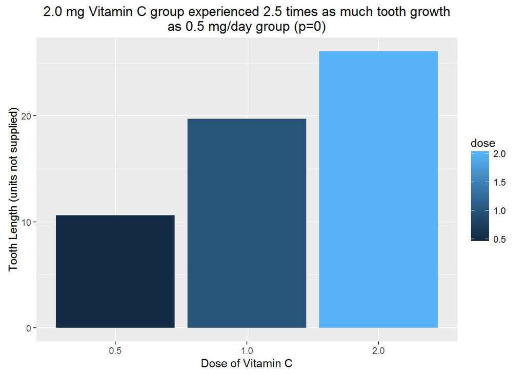

```r
doseplot <- ggplot(mean_dose,aes(c("0.5","1.0","2.0"),mdose))
doseplot + geom_bar(stat="identity",aes(fill=dose))+labs(title="2.0 mg Vitamin C group experienced 2.5 times as much tooth growth\nas 0.5 mg/day group (p=0)",x="Dose of Vitamin C",y="Tooth Length (units not supplied)")
```

#### Conclusion

Based on the first T test, there was no significance in tooth growth based upon the means of delivery of vitamin C. Based on the second T test, the animals receiving 2.0 mg/day experienced 2.5 times as much tooth growth as the group receiving 0.5 mg/day. This suggests that more is better, pending any additional evidence about contraindications that would need to be taken into account.

#### Assumptions

For the conclusions drawn about this sample of guinea pigs to have a potential to play into real-world decisions about the guinea pig population, the subjects are assumed to have been drawn from the population with proactive researcher care towards not overstating or understating any confounding variables, to the best of their ability. There is also an innate assumption involved in skipping some tests. When we failed to reject the null hypothesis in considering the difference between ascorbic acid and orange juice across the three dosages, we then assumed that we did not need to seek out possible differences within dosage subgroups within a delivery. The same is also true along the other dimension.